# Introduction to prettyB

Colin Gillespie

## Introduction

The **prettyB** changes the default values of some standard plotting functions. It is **not** a replacement for **ggplot2** (or other plotting packages), instead, it’s meant to just make the base graphics a little bit nicer. Due to the underlying structure of base graphics & S3 objects, some things aren’t possible. In particular, changing how non-exported plot-methods are displayed.

The general idea is the argument signitures are exactly the same as base graphics. But there are just a bit prettier. The current methods that are available are

- `plot_p()`
- `barplot_p()`
- `boxplot_p()`
- `hist_p()`

## Histogram examples

The important point to note with this histogram method is the `breaks` argument now has a new default. Instead of `breaks = "Sturges"`, the default is `breaks = "fd"`. In general, this is a better default (but not always)

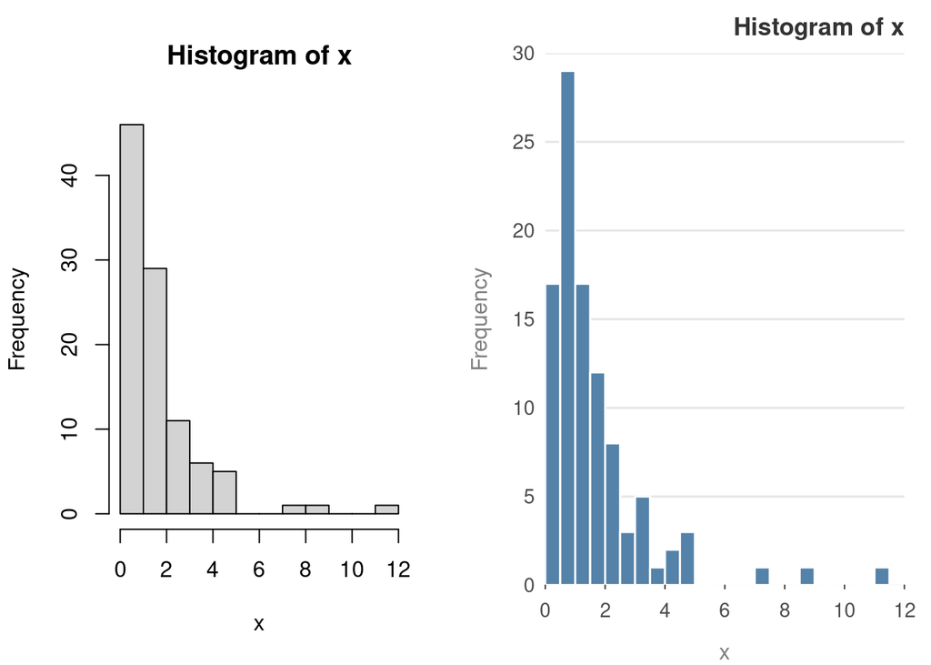

```r
x = rlnorm(100)
hist(x)
hist_p(x)
```

Standard arguments work as well

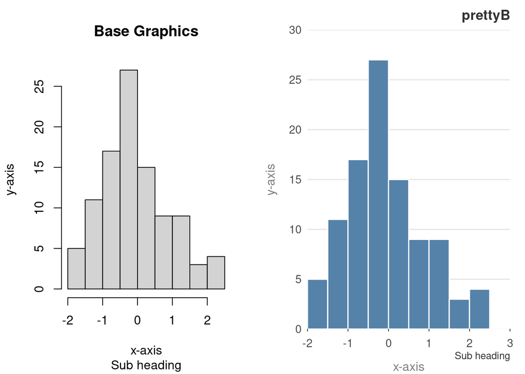

```r
y = rnorm(100)
hist(y, main = "Base Graphics", sub = "Sub heading",
                       xlab = "x-axis", ylab = "y-axis")
hist_p(y, main = "prettyB",  sub = "Sub heading", xlab = "x-axis", ylab = "y-axis")
```

Colours and frequencies also work as is expected

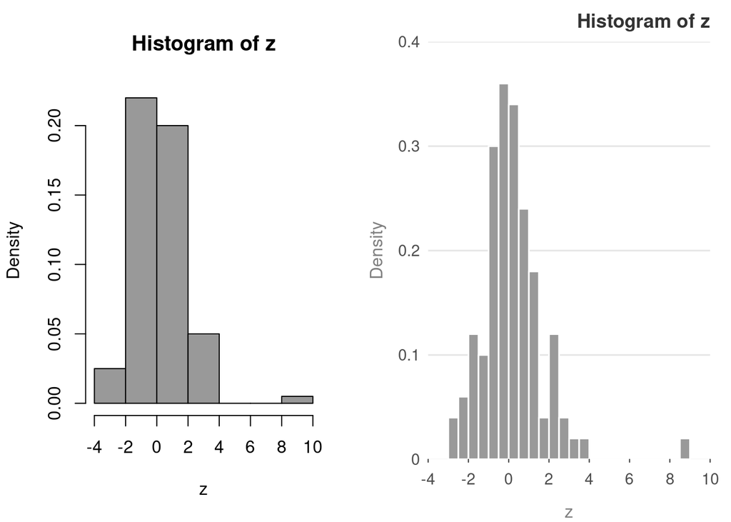

```r
z = rt(100, 4)
hist(z, col = "grey60", freq = FALSE)
hist_p(z, col = "grey60", freq = FALSE)
```

## Barplot examples

The `barplot()` has an amazing number of different configurations.

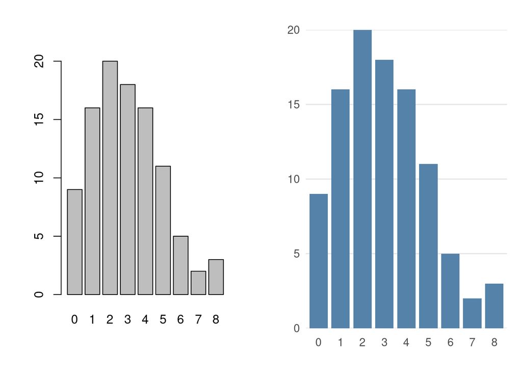

```r
op = par(mfrow = c(1, 2))
reset_prettyB()
library("grDevices") # for colours
tN = table(stats::rpois(100, lambda = 3))
barplot(tN)
barplot_p(tN)
```

The following examples are taken directly from the example page of `?barplot`. This means that sometimes the colours clash.

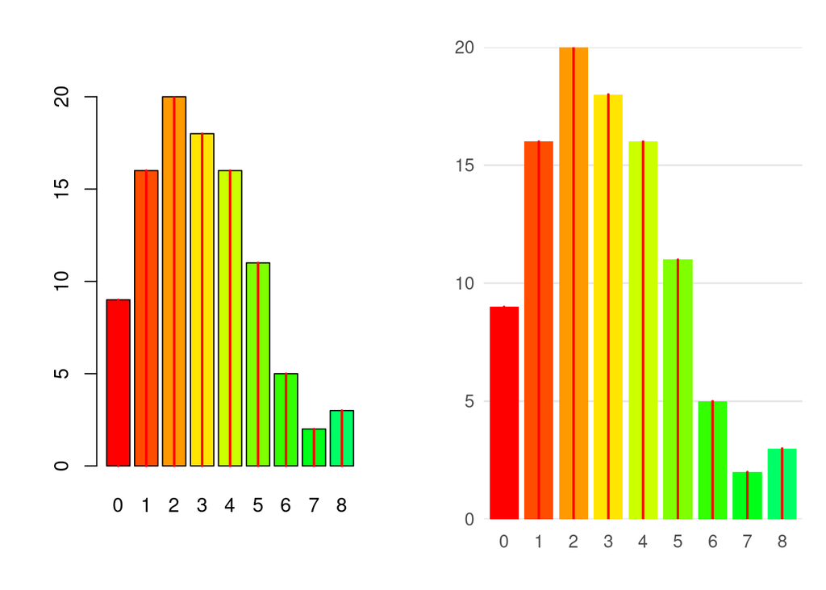

```r
reset_prettyB()
r = barplot(tN, col = rainbow(20))
#- type = "h" plotting *is* 'bar'plot
lines(r, tN, type = "h", col = "red", lwd = 2)
r = barplot_p(tN, col = rainbow(20))
#- type = "h" plotting *is* 'bar'plot
lines(r, tN, type = "h", col = "red", lwd = 2)
```

Spacing and titles still work

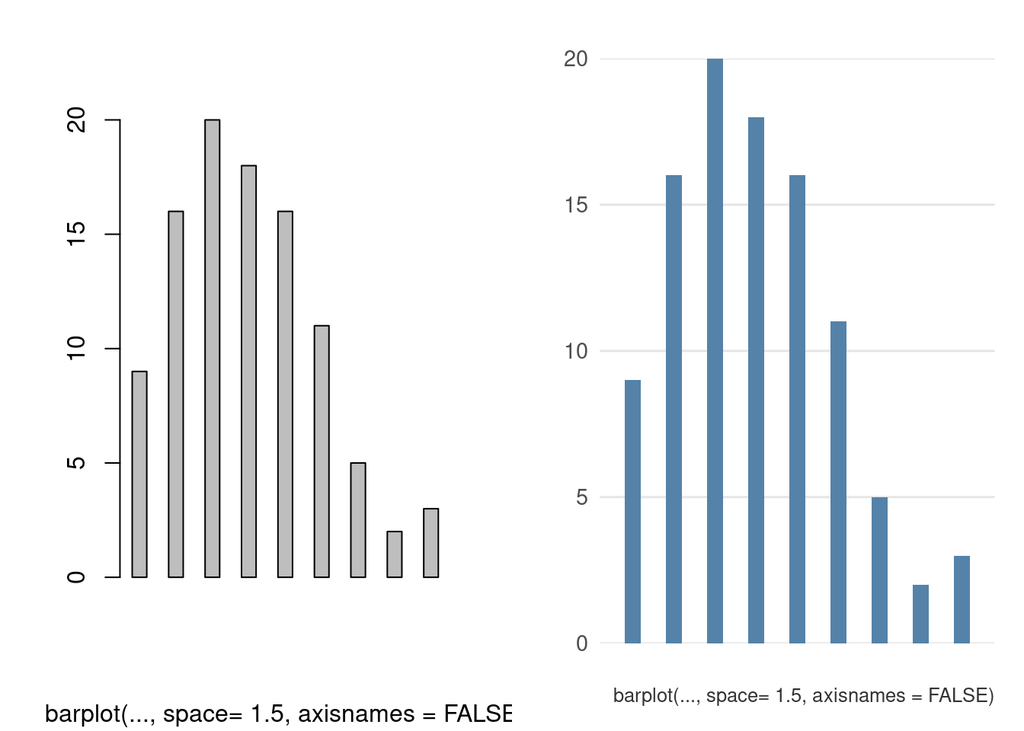

```r
reset_prettyB()
barplot(tN, space = 1.5, axisnames = FALSE,
        sub = "barplot(..., space= 1.5, axisnames = FALSE)")
barplot_p(tN, space = 1.5, axisnames = FALSE,
        sub = "barplot(..., space= 1.5, axisnames = FALSE)")
```

So does the `beside` argument.

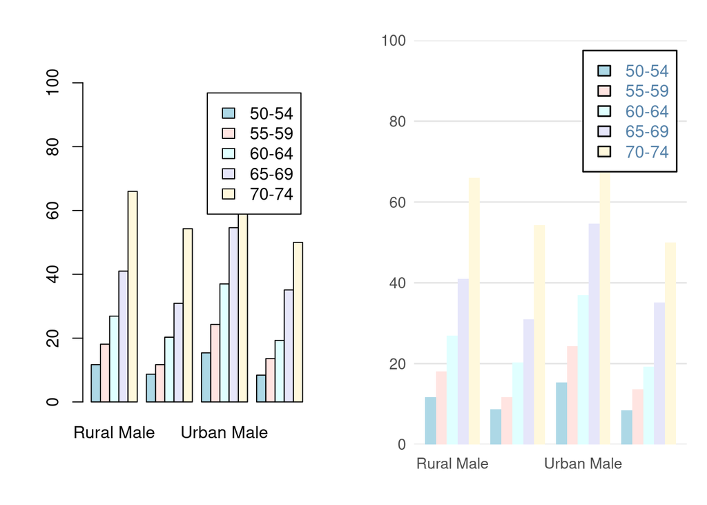

```r
reset_prettyB()
barplot(VADeaths, beside = TRUE,
        col = c("lightblue", "mistyrose", "lightcyan",
                "lavender", "cornsilk"),
        legend = rownames(VADeaths), ylim = c(0, 100))

barplot_p(VADeaths, beside = TRUE,
        col = c("lightblue", "mistyrose", "lightcyan",
                "lavender", "cornsilk"),
        legend = rownames(VADeaths), ylim = c(0, 100))
```

## Other plotting methods

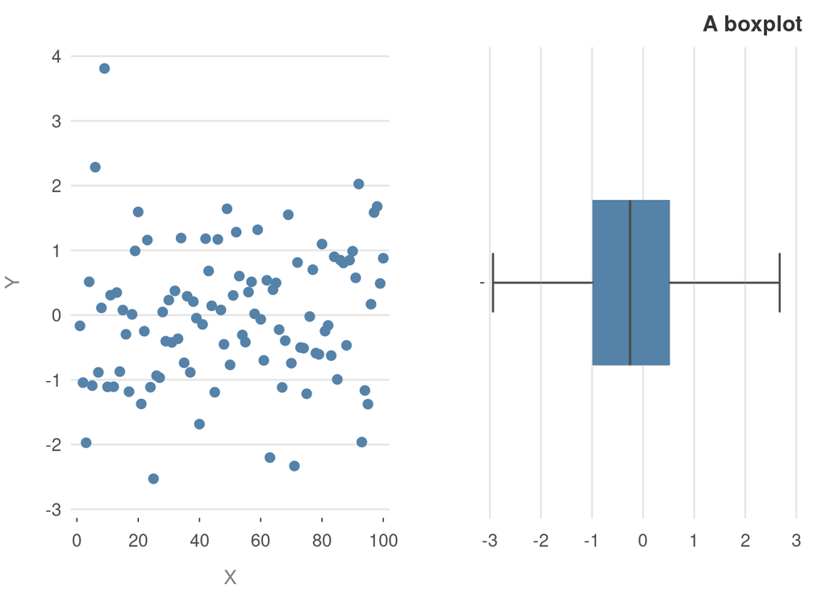

```r
par(mfrow = c(1, 2))
plot_p(1:100, rnorm(100), xlab = "X", ylab = "Y")
boxplot_p(rnorm(100), horizontal = TRUE,
          main = "A boxplot")
```